# Exploratory data analysis

Dominik Klepl

11/26/2019

```r
pacman::p_load(ggplot2, ggthemes, tidyr, gridExtra, extrafont, patchwork)
```

Load the dataset

```r
data = read.csv("data/x_y.csv", header = F)
```

Rename the column names to x and y

```r
colnames(data) = c("x", "y")
```

Add time variable to preserve the time-series structure

## Relationship between x and y

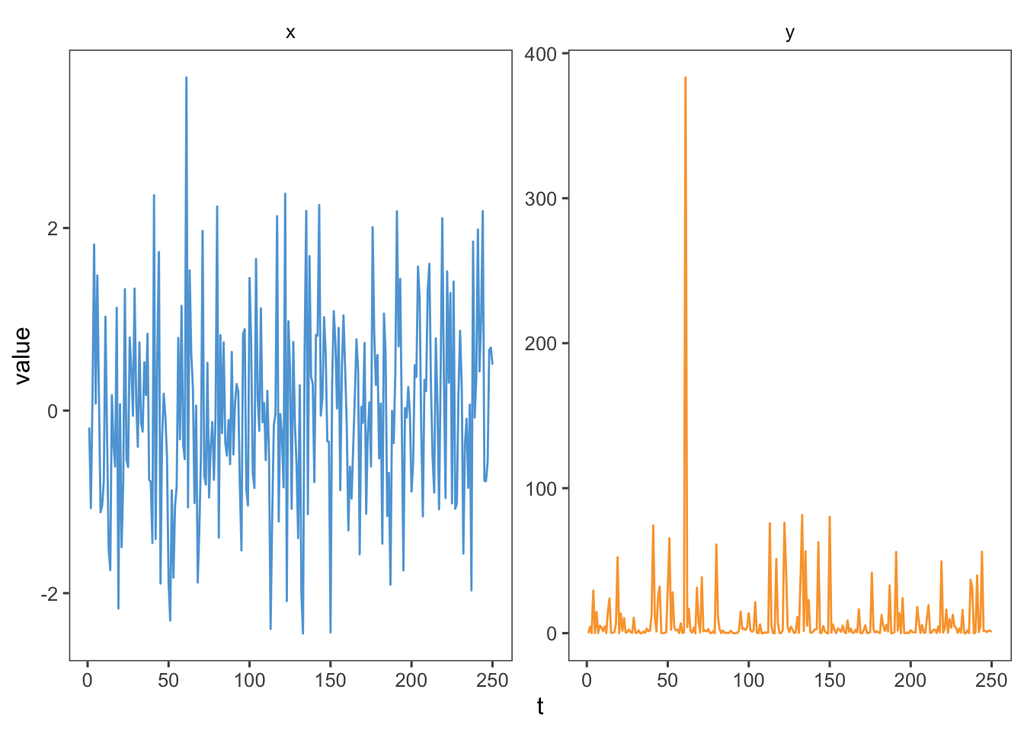

Now we also plot the signals against each other.

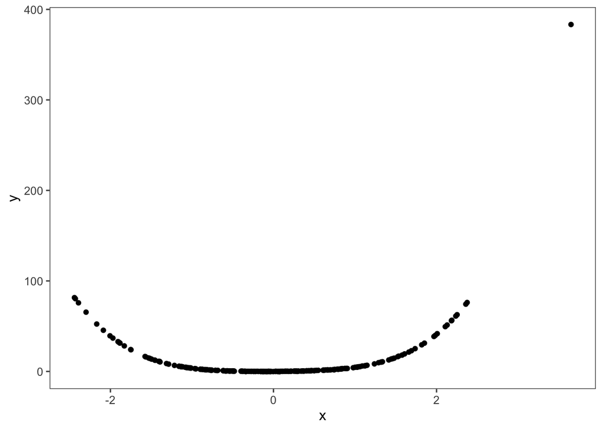

One point seems to be an **outlier**.

It might be a good idea to to remove the outlier now for plotting so that we have a more detailed (zoomed-in) look at the rest of the datapoints.

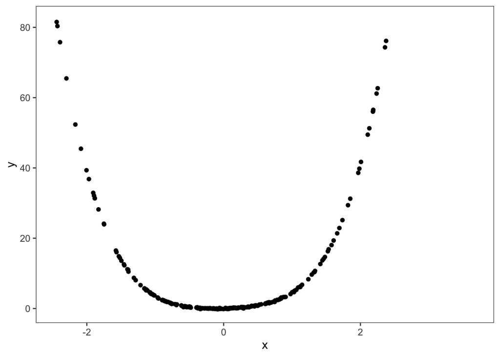

The x^2 component is even clearer in the zoomed-in view.

Plot p1 and x_y_plot together in one *beautiful* plot.

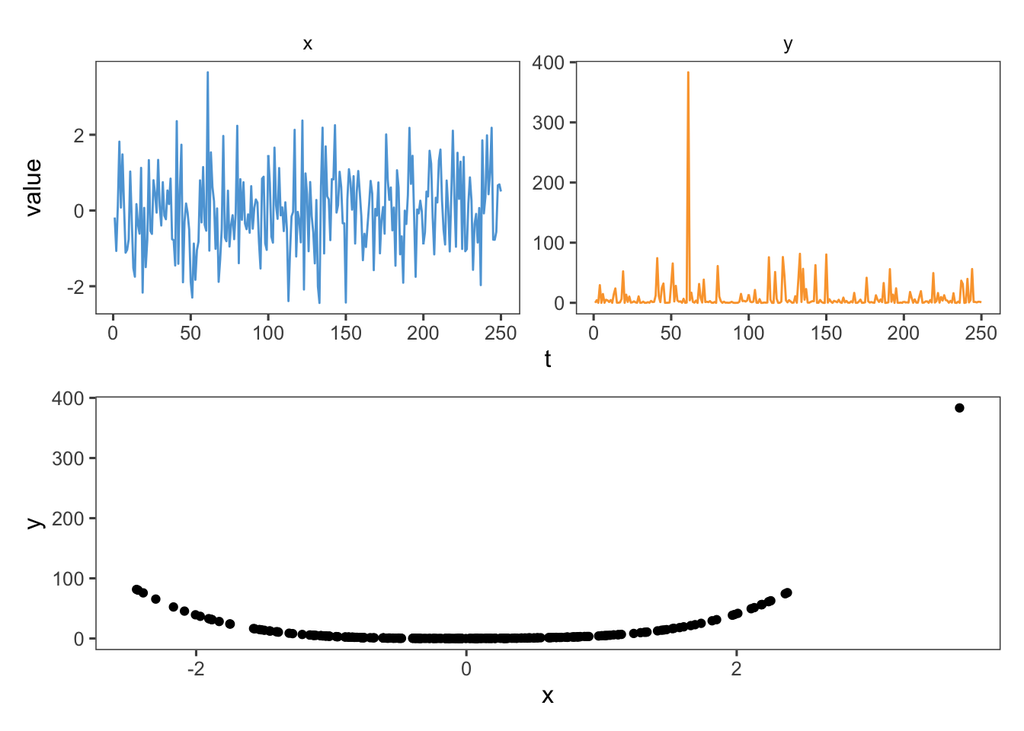

From the scatterplot of the x and y variables we can assume that the a x^2 might be a good parameter for the model.

### Correlation test

We can formally test whether there is correlation between x and y. Although we can already tell from the scatterplot that there must be some correlation. We can use **pearson’s correlation coefficient**, testing hypothesis that true correlation differs from 0.

```
##
##  Pearson's product-moment correlation
##
## data:  data$x and data$y
## t = 3.5408, df = 248, p-value = 0.0004763
## alternative hypothesis: true correlation is not equal to 0
## 95 percent confidence interval:
##  0.09796534 0.33433385
## sample estimates:
##       cor
## 0.2193661
```

There is small positive correlation between the two variables. Null hypothesis was rejected.

## Distributions

Now we inspect the distribution of both x and y

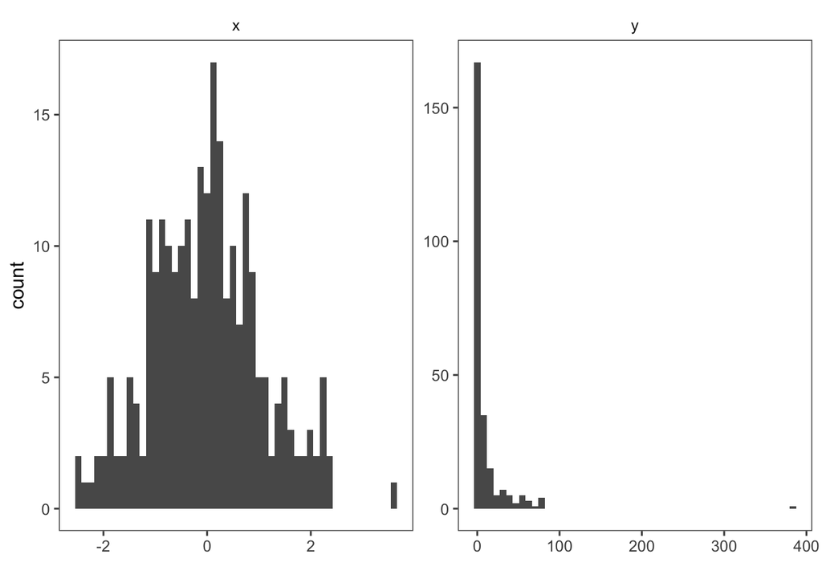

### QQ-plots

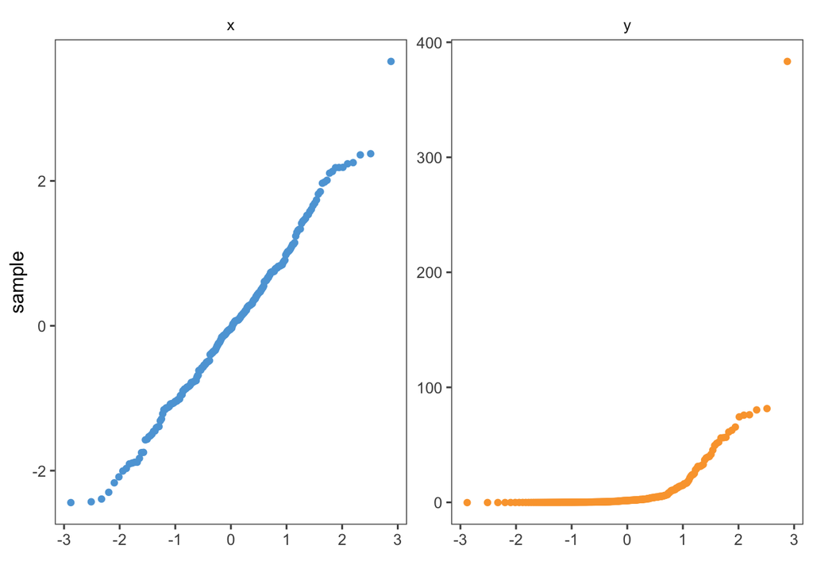

Combine histograms and qqplots into one beautiful plot

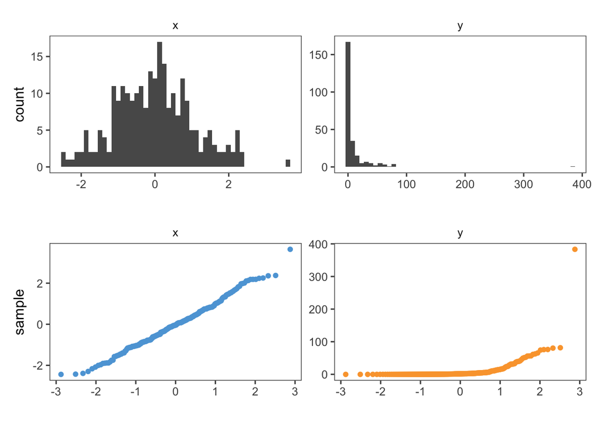

### Further tests of normality

We can use Shapiro-Wilk test which tests the hypothesis whether variable is normally distributed. (Hoping for p-value < .05)

```
## Testing signal x
```

```
##
##  Shapiro-Wilk normality test
##
## data:  data$x
## W = 0.99297, p-value = 0.2854
```

```
## Testing signal y
```

```
##
##  Shapiro-Wilk normality test
##
## data:  data$y
## W = 0.32323, p-value < 2.2e-16
```

#### Just for fun - Is y log-normal?

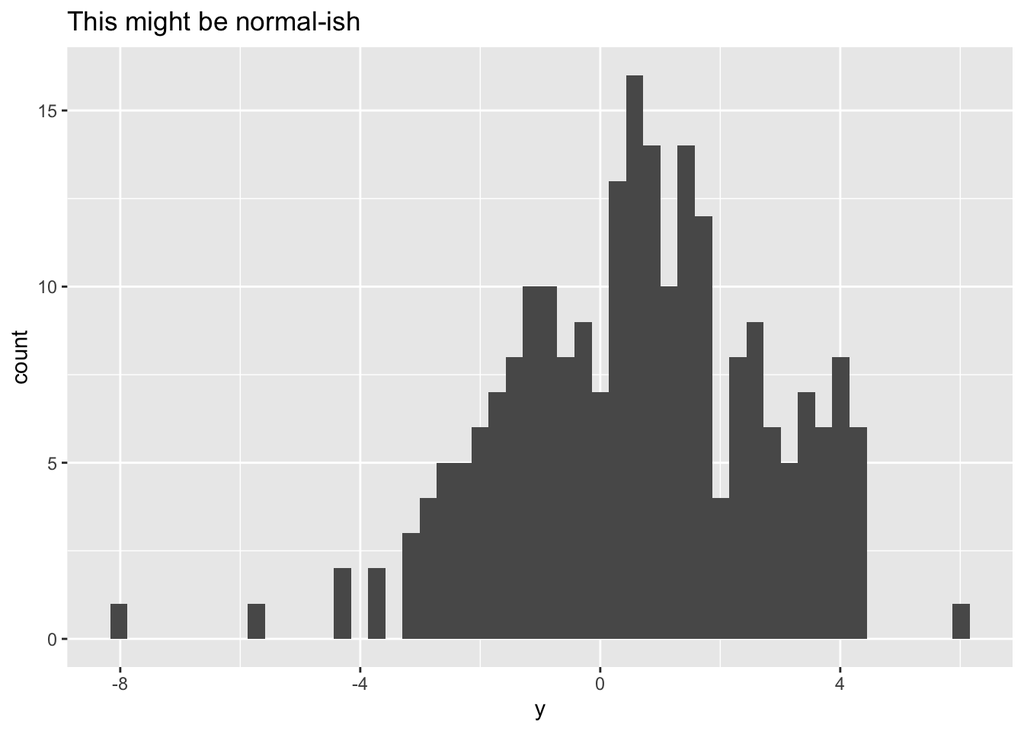

```
## How normal is log(y)?
```

```
##
##  Shapiro-Wilk normality test
##
## data:  log_norm$y
## W = 0.98585, p-value = 0.02352
```

[output not shown]

#### Boxplots and violin plots

Let’s continue with other tests about properties of the signals. First use boxplot and violin plots.

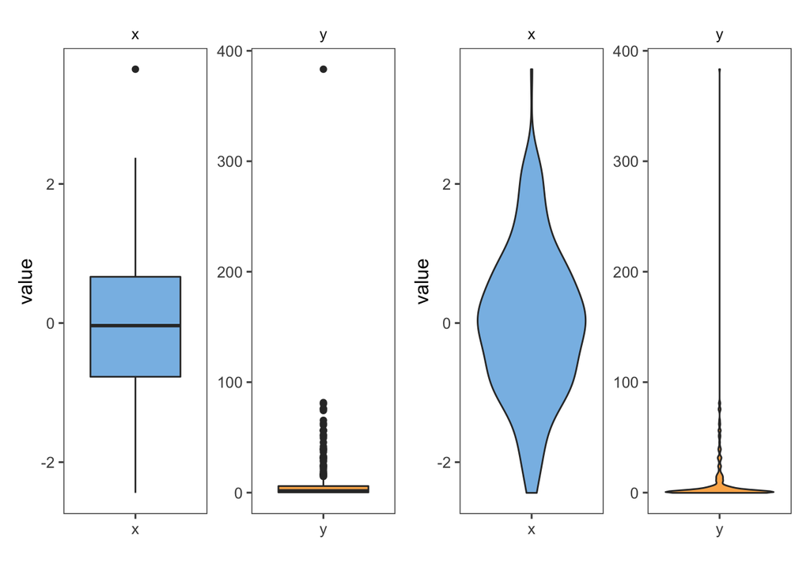

### Fit linear model

Try to fit a linear model with just one parameter: y ~ ß1*x

```
## MSE of the fitted model is: 886.242
```

Residual analysis

```
## Residual analysis:
```

```
##        Min        25%     Median        75%        Max
##  -2.494014  -1.002830   2.178198   9.676968 361.995873
```

Plot residuals and qqplot

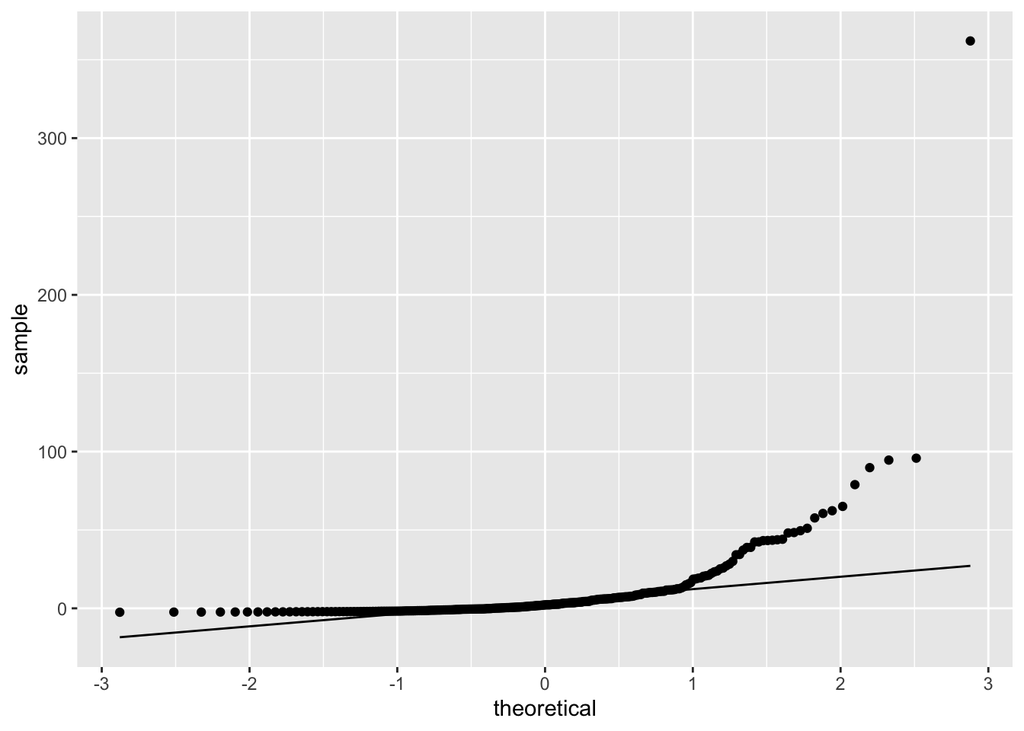

Plot model’s predictions + 95% confidence intervals

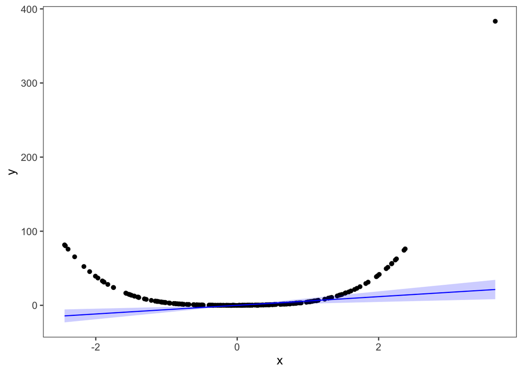

## A bit of “cheating”

Just for fun, ggplot has function for fitting a simple linear model (including confidence intervals). There’s also function for fitting a local polynomial surface/line which basically tries to find the best polynomial model (yes exactly what is our task in the coursework).

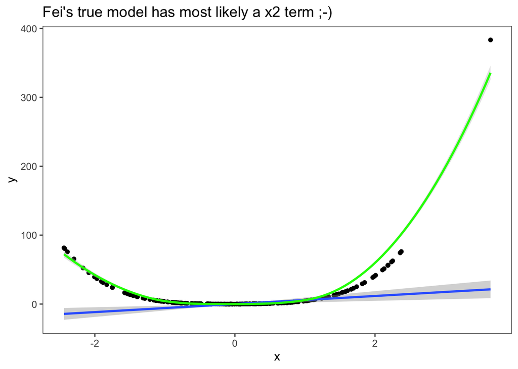